# CMSC320_Final_Project

### Scatterplots

Let's plot some of these audio features in a scatterplot with each other. We will use Valence mainly compared to other attributes instead of looking at all the audio features together. This will provide us another visual example to take a look at.

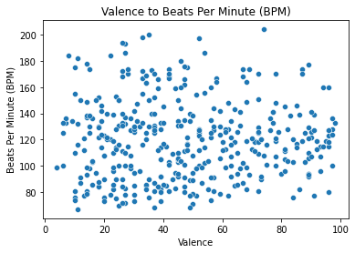

```python
sns.scatterplot(data=pop_songs, x="Valence", y="Beats Per Minute (BPM)")
plt.title("Valence to Beats Per Minute (BPM)")
plt.show()
```

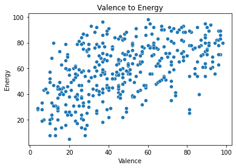

```python
sns.scatterplot(data=pop_songs, x="Valence", y="Energy")
plt.title("Valence to Energy")
plt.show()
```

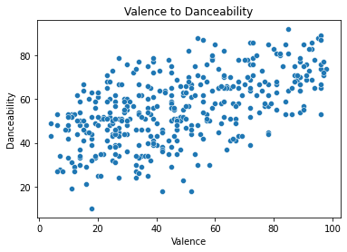

```python
sns.scatterplot(data=pop_songs, x="Valence", y="Danceability")
plt.title("Valence to Danceability")
plt.show()
```

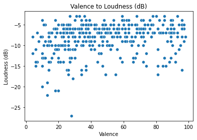

```python
sns.scatterplot(data=pop_songs, x="Valence", y="Loudness (dB)")
plt.title("Valence to Loudness (dB)")
plt.show()
```

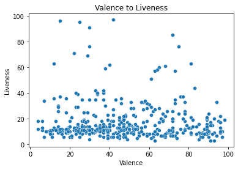

```python
sns.scatterplot(data=pop_songs, x="Valence", y="Liveness")
plt.title("Valence to Liveness")
plt.show()
```

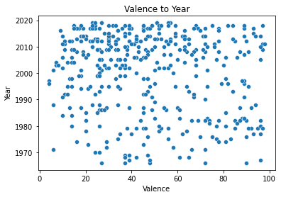

```python
sns.scatterplot(data=pop_songs, x="Valence", y="Year")
plt.title("Valence to Year")
plt.show()
```

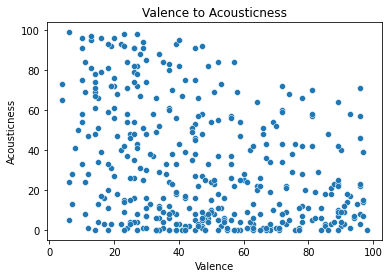

```python
sns.scatterplot(data=pop_songs, x="Valence", y="Acousticness")
plt.title("Valence to Acousticness")
plt.show()
```

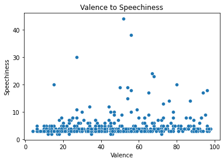

```python
sns.scatterplot(data=pop_songs, x="Valence", y="Speechiness")
plt.title("Valence to Speechiness")
plt.show()
```

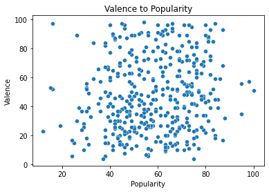

```python
sns.scatterplot(data=pop_songs, x="Popularity", y="Valence")
plt.title("Valence to Popularity")
plt.show()
```

We can take see that the plot with the best positive trend is Valence and Danceability. This makes sense as the more positive a song is, you would most likely expect someone to enjoy the song through dancing. This also reflects what we found in the heatmap. There is also other scatterplots just look like there is a bunch of points everywhere with little to no correlation or skew.

## Hypothesis Testing and Machine Learning

The goal is to use machine learning to predict the Valence in pop songs. There are 9 other audio features to look into and inspect their impact on a song's Valence. Linear Regression will be used to model the relationship between two variables by fitting a linear equation to observed data. A linear regression line has an equation of the form Y = a + bX. X is the explanatory variable while Y is the dependent variable.

#### Null Hypothesis:

- There are some relationship between Valence of a song and other audio features!

#### Statsmodel's Ordinary Least Square Model (OLS)

We will use this [model](https://www.statsmodels.org/dev/examples/notebooks/generated/ols.html) to create a linear regression model. The dependent variable is Valence while the independent variables will be the other audio features (Beats Per Minute (BPM), Energy, Danceability, Loudness (dB), Liveness, Length (Duration), Acousticness, Speechiness, Popularity).

#### Linear Regression

We will attempt to measure how close data points are to the fitted regression line by calculating the R-squared score.

- The scores range from 0 to 1
- The closer the value to 1, the more accurate the data is. The closer the value is to 0, the more inaccurate data is.

Most of the concepts used here will not need to be done from scratch since there are libraries and existing implementations we imported earlier in the tutorial. We will mainly use [sklearn](https://scikit-learn.org/stable/), which is a popular machine learning libary with a variety of features that will aid us in exploring our hypothesis. More information on the Least Ordinary Square and Linear Regression provided at the end of the tutorial.

```python
# audio_feats will exclude Valence
audio_feats = ['Beats Per Minute (BPM)','Energy', 'Danceability', 'Loudness (dB)',
               'Liveness', 'Length (Duration)', 'Acousticness', 'Speechiness', 'Popularity']


x = pop_songs[audio_feats]  # Dataframe that holds all the audio features apart from Valence
y = pop_songs['Valence']  # Dataframe that holds all the Valence related stats

# Fits the data and helps us look at a Least Ordinary Square summary
ols = api.OLS(y,x).fit()
ols.summary2()
```

| Model: | OLS | Adj. R-squared (uncentered): | 0.895 |
| --- | --- | --- | --- |
| Dependent Variable: | Valence | AIC: | 3414.9361 |
| Date: | 2021-05-16 14:33 | BIC: | 3450.8142 |
| No. Observations: | 398 | Log-Likelihood: | -1698.5 |
| Df Model: | 9 | F-statistic: | 377.7 |
| Df Residuals: | 389 | Prob (F-statistic): | 3.45e-186 |
| R-squared (uncentered): | 0.897 | Scale: | 304.91 |

|  | Coef. | Std.Err. | t | P>\|t\| | [0.025 | 0.975] |
| --- | --- | --- | --- | --- | --- | --- |
| Beats Per Minute (BPM) | -0.0189 | 0.0285 | -0.6617 | 0.5085 | -0.0749 | 0.0372 |
| Energy | 0.6018 | 0.0616 | 9.7764 | 0.0000 | 0.4807 | 0.7228 |
| Danceability | 0.6609 | 0.0627 | 10.5494 | 0.0000 | 0.5378 | 0.7841 |
| Loudness (dB) | -1.2119 | 0.3074 | -3.9423 | 0.0001 | -1.8163 | -0.6075 |
| Liveness | -0.1040 | 0.0594 | -1.7505 | 0.0808 | -0.2208 | 0.0128 |
| Length (Duration) | -0.0870 | 0.0132 | -6.6078 | 0.0000 | -0.1129 | -0.0611 |
| Acousticness | -0.0184 | 0.0379 | -0.4853 | 0.6277 | -0.0930 | 0.0562 |
| Speechiness | -0.1065 | 0.2176 | -0.4896 | 0.6247 | -0.5344 | 0.3213 |
| Popularity | -0.1231 | 0.0557 | -2.2107 | 0.0276 | -0.2326 | -0.0136 |

| Omnibus: | 3.475 | Durbin-Watson: | 2.077 |
| --- | --- | --- | --- |
| Prob(Omnibus): | 0.176 | Jarque-Bera (JB): | 2.802 |
| Skew: | -0.088 | Prob(JB): | 0.246 |
| Kurtosis: | 2.629 | Condition No.: | 108 |

We can see that there is quite a bit of information to take in from this table. While there are other interesting areas to look at, the most important column we should look at currently is the P>|t| column. This is the p-value of each audio feature!

- P-Value: Probability that the null hypothesis is true.
- P-Value Range: -1 < c < 1, with 1 being linear positive and -1 being linear negative slope.
- If a P-Value is less than 0.05, this means there is a higher statistical significance.

We can see that Loudness (dB) and Popularity have a lower value than 0.05! This is important because it tells us that our null hypothesis is true and that there is significant correlation! We can also see that there are some values in the column that are just 0.0 values. This is strange and could be a result of the summary not showing more decimal numbers.  
Luckily, there is a way to output the p-values directly. Check out the code below:

```python
ols.pvalues
```

```
Beats Per Minute (BPM)    5.085263e-01
Energy                    2.493748e-20
Danceability              4.742400e-23
Loudness (dB)             9.571132e-05
Liveness                  8.082127e-02
Length (Duration)         1.286127e-10
Acousticness              6.277212e-01
Speechiness               6.246892e-01
Popularity                2.763738e-02
dtype: float64
```

This is also great because now we can see a lot better that there are also other audio features that have P-Values lower than 0.05. We now can see that Energy and Danceability have significance.  
We can also use Pearson's correlation to see another perspective on our p-values from earlier. Pearson's correlation coefficient is used to summarize the strength of the linear relationship between two data samples. We will check the p-values of Energy, Danceability, Loudness, and Popularity to Valence.

```python
# Getting the P-Values through Pearson's correlation coefficient method
print("Pearson's Correlation P-Values:")
p = pearsonr(data['Valence'], data['Energy'])
print("P-Value for Valence and Energy:", p[1])
p = pearsonr(data['Valence'], data['Danceability'])
print("P-Value for Valence and Danceability:", p[1])
p = pearsonr(data['Valence'], data['Loudness (dB)'])
print("P-Value for Valence and Loudness (dB):", p[1])
p = pearsonr(data['Valence'], data['Popularity'])
print("P-Value for Valence and Popularity:", p[1])
print('\n')
```

```
Pearson's Correlation P-Values:
P-Value for Valence and Energy: 1.1877862303821174e-79
P-Value for Valence and Danceability: 3.1208607711013127e-135
P-Value for Valence and Loudness (dB): 4.1735452163699535e-11
P-Value for Valence and Popularity: 1.786482609798892e-05
```

We can see that the P-values calculated through Pearson's correlation coefficient shows similar outcomes and trend as the OLS summary's values.  
We will agree with the null hypothesis!

### Prediction of Valence Based on Other Features

Here we will use sklearn and their linear_model capabilities.

```python
lr = linear_model.LinearRegression().fit(x,y)
rsquared = lr.score(x,y)
print("R-squared Value:",rsquared)
```

```
R-squared Value: 0.5390775849549849
```

We get a value of 0.53 which is not as ideal as we would want. This means there is at least some variability in the data that cannot be accounted for by the model. The value basically means about 54% of the model's prediction will be accurate to the actual Valence values.

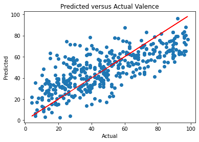

```python
prediction = lr.predict(x)
plt.scatter(y, prediction)
plt.plot(y, y, color="red")
plt.xlabel("Actual")
plt.ylabel("Predicted")
plt.title("Predicted versus Actual Valence")
plt.show()
```

It seems that there is not a close fit. The data points range throughout 0 to 100. So this plot does reflect the R-squared value we found earlier. We can see that there are some clustering of data points at certain points near the regression line. For example, we can see some clustering towards the 50% actual and 50% predicted.

## Conclusion

#### Further Findings and Thoughts

So unfortunately we are not able to completely conclude whether there are audio features or attributes that would clearly predict a song's valence. However, there was some interesting correlations found that could be researched into more. It was nice to see that Valence and Danceability complemented each other. Same with Valence and Energy. In hindsight, this makes sense at least to me when I listen to Pop music, I am trying to experience something positive. The predictive model we used was able to calculate a R-squared score of 0.53 which can explain some areas of Valence through some audio features.  
Overall, the way someone views positivity of a song could very well be completely different to another person. It is important to remember that no song is universally positive for an individual. Additionally, songs can also change throughout its duration. For example, the Beats Per Minute can change or lyrics could convey a different message even if the song has a more upbeat instrumental. It is also critical to note that pop songs do not have to be positive. There are some great 'sadder' pop songs that can still put people in a good mood or cheer them up in other special ways. In the end, the way someone experiences the Valence of a song is subjective.  
Hopefully this tutorial was interesting and fun to explore! It felt rewarding to code and explore my findings while wrapping up my time in CMSC320. I also enjoyed the EDA portion. It allowed me visualize stats that would not have made much sense to me unless I saw a nice graphic for it. I found a lot of insightful information especially to Spotify's music library as a whole. Maybe you were able to spot and find something captivating that I missed. If you want to explore the idea of predicting another audio feature, maybe try using the entire dataset or similar datasets with similar audio features available. You could even search for the top songs on spotify each year and see if Valence vary from different time periods. The next time you listen to a Pop song, don't forget to pay attention to the different audio features to see how uplifting the song is!

## Additional Resources

In case there were some confusing packages, code, or concepts used in this tutorial, explore these links to see if they help you figure out some difficulties. Or just research more into the different things used!

- [Kaggle Link to Data Set Used in this tutorial](https://www.kaggle.com/iamsumat/spotify-top-2000s-mega-dataset)
- [Kaggle: website to explore data, publish data sets, and build models](https://www.kaggle.com)
- [Seaborn: Python data visualization library based on matplotlib](https://seaborn.pydata.org/)
- [Heatmap Documentation](https://seaborn.pydata.org/generated/seaborn.heatmap.html)
- [sklearn: Machine Learning tools for predictive data analysis](https://scikit-learn.org/stable/)
- [Additional tutorial link for Pearson's Correlation](https://machinelearningmastery.com/how-to-use-correlation-to-understand-the-relationship-between-variables/)
- [More information on Ordinary Least Squares Regression](https://setosa.io/ev/ordinary-least-squares-regression/)
- [More information on Linear Regression](https://www.statisticssolutions.com/what-is-linear-regression/)
- [Pandas: Open source data analysis and manipulation tool](https://pandas.pydata.org/)
- [NumPy: The fundamental package for scientific computing with Python](https://numpy.org/)
- [Matplotlib: comprehensive library for creating static, animated, and interactive visualizations in Python.](https://numpy.org/)
- [Spotify API. This wasn't used in the tutorial but could open up more doors to you if you want to explore other parts of Spotify!](https://developer.spotify.com/documentation/web-api/)
- [Regular Expression in Python](https://www.w3schools.com/python/python_regex.asp)